# Models segons la retirada d’estatines

Eudald Correig

25/6/2020

# Formateig

Traiem les resines i l’omacor perquè tenen massa poca variabilitat.

Nota: canvio el nom d’Antiagregants.Anticoagulants a A.A perquè si no ocupa massa i les coses es veuen malament.

Mirem quantes dates d’ingrés o alta ens falten:

Hi ha 2 pacients dels quals no tenim la data d’ingrés. Els traiem.

Fem una variable que controla quin esdeveniment de sortida (outcome) té cada pacient:

Hi ha encara algun pacient que té 0 dies d’estada:

```
##  [1] "3-093"  "3-099"  "09-101" "09-120" "10-107" "11-044" "13-129"
##  [8] "13-197" "19-022" "20-074"
```

Sumem un dia a tots

Traiem els pacients que tenen pes 0.

# Anàlisi univariant

Fem un test de chi^2 per entre prendre estatines o no i morir de covid o no:

```
##
##
##    Cell Contents
## |-------------------------|
## |                       N |
## | Chi-square contribution |
## |           N / Row Total |
## |           N / Col Total |
## |         N / Table Total |
## |-------------------------|
##
##
## Total Observations in Table:  1350
##
##
##              |               No |               Sí |        Row Total |
## -------------|------------------|------------------|------------------|
##           No |              587 |              179 |              766 |
##              |            0.227 |            0.811 |                  |
##              |            0.766 |            0.234 |            0.568 |
##              |            0.557 |            0.608 |                  |
##              |            0.435 |            0.133 |                  |
## -------------|------------------|------------------|------------------|
##    Retirades |              189 |               54 |              243 |
##              |            0.003 |            0.012 |                  |
##              |            0.778 |            0.222 |            0.180 |
##              |            0.179 |            0.183 |                  |
##              |            0.140 |            0.040 |                  |
## -------------|------------------|------------------|------------------|
##           Sí |              278 |               62 |              340 |
##              |            0.584 |            2.083 |                  |
##              |            0.818 |            0.182 |            0.252 |
##              |            0.264 |            0.210 |                  |
##              |            0.206 |            0.046 |                  |
## -------------|------------------|------------------|------------------|
## Column Total |             1054 |              295 |             1349 |
##              |            0.781 |            0.219 |                  |
## -------------|------------------|------------------|------------------|
##
##
## Statistics for All Table Factors
##
##
## Pearson's Chi-squared test
## ------------------------------------------------------------
## Chi^2 =  3.720237     d.f. =  2     p =  0.1556542
##
##
##
```

Fem un gràfic:

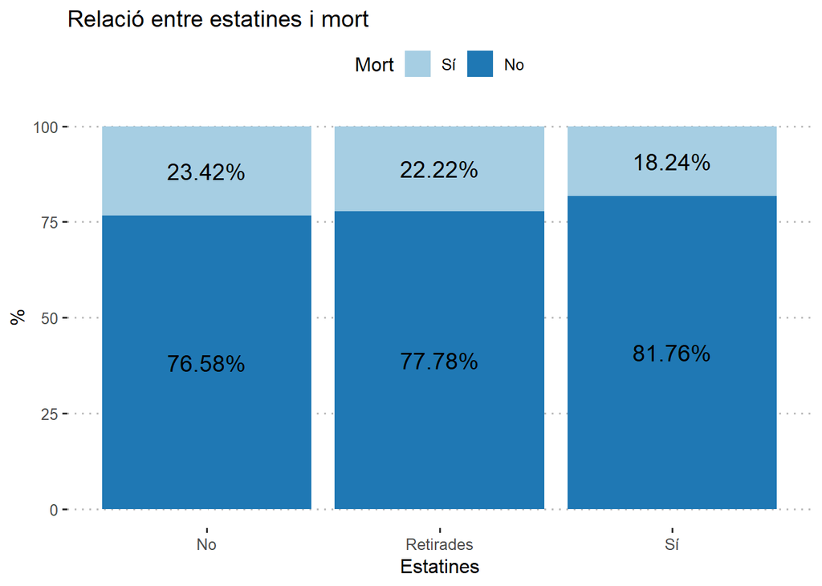

# Model de supervivència

Primer dibuixem una Kaplan Meier:

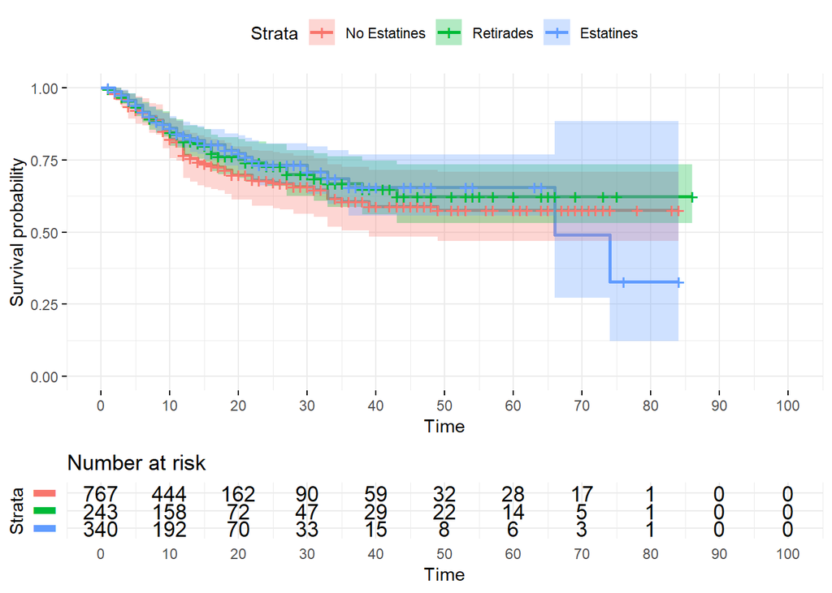

L’efecte és petit, però hi és.

## Cause specific hazard ratio

Estratifiquem per sexe.

Tenim els següents esdeveniments:

```
##
## censura    alta    mort
##      15    1096     239
```

### Mort

```
## Call:
## coxph(formula = Surv(as.numeric(temps), esdeveniment == "mort") ~
##     . - Mort - weights - Sexe + strata(Sexe), data = df, weights = df$weights,
##     ties = "efron")
##
##   n= 1350, number of events= 239
##
##                         coef exp(coef)  se(coef) robust se      z Pr(>|z|)
## Edat                0.072532  1.075227  0.007864  0.010828  6.699  2.1e-11
## TabacExfumador      0.084111  1.087750  0.164089  0.262323  0.321  0.74848
## TabacSí             0.250888  1.285166  0.305171  0.533356  0.470  0.63807
## HTASí              -0.076488  0.926364  0.193471  0.276257 -0.277  0.78188
## HiperlipemiaSí      0.304844  1.356413  0.225844  0.263466  1.157  0.24725
## DiabetesSí         -0.200980  0.817929  0.221194  0.396464 -0.507  0.61220
## ObesitatSí          0.017874  1.018035  0.148759  0.209713  0.085  0.93208
## Ant.CISí           -0.686879  0.503144  0.182753  0.255474 -2.689  0.00717
## Ant.IctusSí         0.180290  1.197564  0.171869  0.256914  0.702  0.48283
## Ant.MVPSí           0.450488  1.569077  0.186621  0.303732  1.483  0.13803
## Ant.Ins.CardSí      0.260465  1.297534  0.172591  0.275951  0.944  0.34523
## Ant.MPOCSí         -0.016952  0.983191  0.147245  0.231982 -0.073  0.94175
## Ant.MHepCSí         0.577998  1.782466  0.372494  0.655665  0.882  0.37802
## Ant.MRCSí           0.357802  1.430182  0.149770  0.241281  1.483  0.13809
## Ant.MReuSí         -0.831780  0.435274  0.337532  0.456533 -1.822  0.06846
## CàncerSí            0.835676  2.306372  0.154400  0.258984  3.227  0.00125
## EstatinesRetirades -0.174429  0.839937  0.180755  0.253944 -0.687  0.49216
## EstatinesSí        -0.397020  0.672321  0.165217  0.227215 -1.747  0.08058
## EzetimibaSí         0.552071  1.736846  0.316355  0.738968  0.747  0.45501
## FibratSí            0.837280  2.310074  0.257855  0.397272  2.108  0.03507
## IECASí             -0.230551  0.794096  0.154495  0.233305 -0.988  0.32306
## ARA2Sí             -0.432211  0.649073  0.191537  0.281683 -1.534  0.12493
## InsulinaSí          0.212497  1.236763  0.208246  0.412474  0.515  0.60643
## ISGLT2Sí           -0.732717  0.480601  0.487151  0.791398 -0.926  0.35452
## GLP1Sí              0.469190  1.598698  0.313591  0.580082  0.809  0.41861
## Trac.DMSí           0.527283  1.694322  0.215900  0.397370  1.327  0.18453
## A.A.NACOs          -0.314856  0.729894  0.250625  0.400652 -0.786  0.43195
## A.A.No             -0.555677  0.573684  0.160066  0.258116 -2.153  0.03133
## A.A.Sintrom        -0.309833  0.733569  0.209744  0.363707 -0.852  0.39428
## CT                  0.142188  1.152793  0.077198  0.124096  1.146  0.25188
## HDL                 0.290123  1.336591  0.263494  0.356886  0.813  0.41626
## LDL                -0.241681  0.785307  0.120629  0.200254 -1.207  0.22748
```

[output cut: 65 more lines]

```
## A.A.NACOs             0.7299     1.3701    0.3328    1.6006
## A.A.No                0.5737     1.7431    0.3459    0.9514
## A.A.Sintrom           0.7336     1.3632    0.3596    1.4963
## CT                    1.1528     0.8675    0.9039    1.4702
## HDL                   1.3366     0.7482    0.6641    2.6902
## LDL                   0.7853     1.2734    0.5304    1.1628
## TG                    1.0394     0.9621    0.9247    1.1683
##
## Concordance= 0.795  (se = 0.022 )
## Likelihood ratio test= 311.5  on 33 df,   p=<2e-16
## Wald test            = 134.7  on 33 df,   p=3e-14
## Score (logrank) test = 318.8  on 33 df,   p=<2e-16,   Robust = 75.09  p=4e-05
##
##   (Note: the likelihood ratio and score tests assume independence of
##      observations within a cluster, the Wald and robust score tests do not).
```

Forest plot:

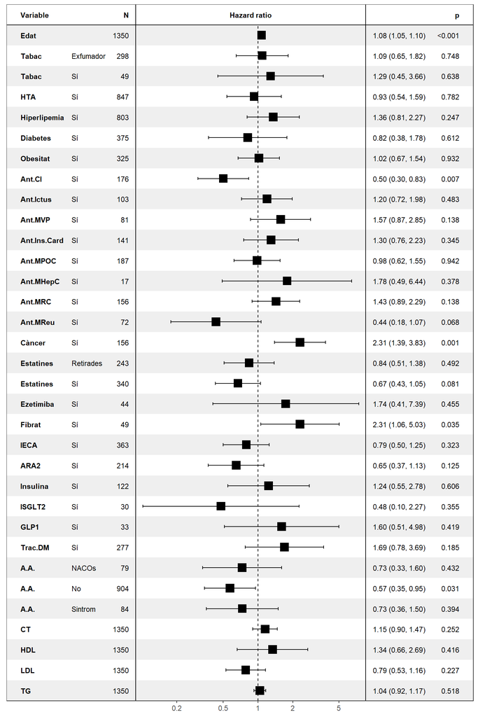

### Alta

```
## Call:
## coxph(formula = Surv(as.numeric(temps), df$esdeveniment == "alta") ~
##     . - weights - Mort, data = df, weights = df$weights, ties = "efron")
##
##   n= 1350, number of events= 1096
##
##                         coef exp(coef)  se(coef) robust se      z Pr(>|z|)
## Edat               -0.005912  0.994105  0.003211  0.004617 -1.281  0.20032
## SexeHome           -0.069383  0.932969  0.079807  0.111307 -0.623  0.53305
## TabacExfumador      0.042102  1.043001  0.083569  0.147849  0.285  0.77583
## TabacSí            -0.310422  0.733138  0.166600  0.260116 -1.193  0.23271
## HTASí              -0.113425  0.892771  0.093553  0.124831 -0.909  0.36355
## HiperlipemiaSí      0.116902  1.124009  0.119123  0.155963  0.750  0.45353
## DiabetesSí          0.053307  1.054753  0.113593  0.155446  0.343  0.73165
## ObesitatSí          0.007535  1.007564  0.073198  0.115979  0.065  0.94820
## Ant.CISí            0.377420  1.458517  0.088843  0.169154  2.231  0.02567
## Ant.IctusSí         0.279420  1.322363  0.112173  0.180301  1.550  0.12120
## Ant.MVPSí          -0.568946  0.566122  0.133709  0.197199 -2.885  0.00391
## Ant.Ins.CardSí     -0.020881  0.979336  0.117987  0.178065 -0.117  0.90665
## Ant.MPOCSí          0.122399  1.130205  0.081849  0.138945  0.881  0.37836
## Ant.MHepCSí        -0.211573  0.809310  0.280193  0.393756 -0.537  0.59105
## Ant.MRCSí           0.118826  1.126174  0.101853  0.194491  0.611  0.54123
## Ant.MReuSí         -0.354276  0.701681  0.122012  0.207924 -1.704  0.08841
## CàncerSí            0.225617  1.253095  0.101100  0.189649  1.190  0.23418
## EstatinesRetirades -0.355140  0.701075  0.093183  0.133571 -2.659  0.00784
## EstatinesSí         0.004399  1.004408  0.081431  0.152809  0.029  0.97704
## EzetimibaSí         0.134046  1.143445  0.173897  0.202724  0.661  0.50847
## FibratSí           -0.164901  0.847978  0.138951  0.196048 -0.841  0.40028
## IECASí              0.062435  1.064425  0.086055  0.137136  0.455  0.64891
## ARA2Sí              0.182299  1.199973  0.097661  0.160054  1.139  0.25471
## InsulinaSí         -0.104642  0.900647  0.121424  0.148661 -0.704  0.48150
## ISGLT2Sí            0.395495  1.485119  0.183630  0.242889  1.628  0.10346
## GLP1Sí              0.305820  1.357738  0.199454  0.179533  1.703  0.08849
## Trac.DMSí          -0.242305  0.784817  0.114043  0.144414 -1.678  0.09338
## A.A.NACOs          -0.077194  0.925710  0.142760  0.172393 -0.448  0.65431
## A.A.No             -0.097335  0.907252  0.088856  0.153149 -0.636  0.52507
## A.A.Sintrom        -0.078579  0.924429  0.129118  0.229012 -0.343  0.73151
## CT                 -0.173198  0.840971  0.078787  0.106400 -1.628  0.10357
## HDL                 0.288229  1.334063  0.140941  0.205221  1.404  0.16017
## LDL                 0.229987  1.258584  0.089076  0.122553  1.877  0.06057
```

[output cut: 67 more lines]

```
## A.A.NACOs             0.9257     1.0803    0.6603    1.2978
## A.A.No                0.9073     1.1022    0.6720    1.2249
## A.A.Sintrom           0.9244     1.0817    0.5901    1.4481
## CT                    0.8410     1.1891    0.6827    1.0360
## HDL                   1.3341     0.7496    0.8923    1.9946
## LDL                   1.2586     0.7945    0.9898    1.6003
## TG                    0.9964     1.0036    0.9249    1.0734
##
## Concordance= 0.627  (se = 0.022 )
## Likelihood ratio test= 129.5  on 34 df,   p=5e-13
## Wald test            = 70.22  on 34 df,   p=3e-04
## Score (logrank) test = 125  on 34 df,   p=2e-12,   Robust = 58.48  p=0.006
##
##   (Note: the likelihood ratio and score tests assume independence of
##      observations within a cluster, the Wald and robust score tests do not).
```

Forest plot:

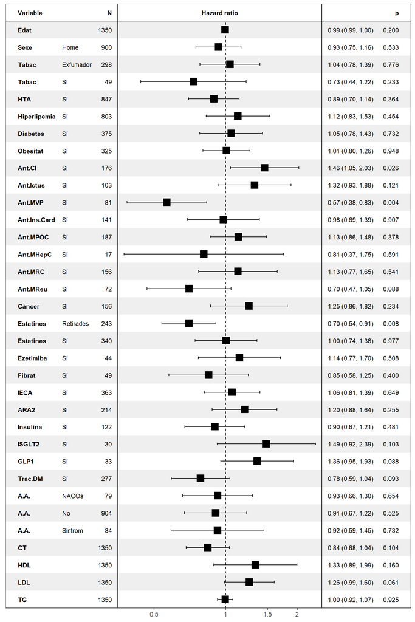

I acabem per un competing risk

## Competing risk

### Mort

```
## Call:
## coxph(formula = Surv(fgstart, fgstop, fgstatus) ~ . - Mort -
##     fgwt - weights, data = fg, weights = fgwt)
##
##   n= 4546, number of events= 239
##
##                         coef exp(coef)  se(coef) robust se      z Pr(>|z|)
## Edat                0.068529  1.070932  0.007788  0.010475  6.542 6.06e-11
## SexeHome            0.301033  1.351253  0.159722  0.315415  0.954 0.339880
## TabacExfumador      0.083470  1.087053  0.164240  0.302652  0.276 0.782706
## TabacSí             0.583114  1.791609  0.288038  0.442517  1.318 0.187597
## HTASí              -0.116521  0.890011  0.197710  0.290931 -0.401 0.688779
## HiperlipemiaSí      0.150663  1.162604  0.226658  0.278265  0.541 0.588207
## DiabetesSí         -0.151933  0.859046  0.224715  0.408716 -0.372 0.710091
## ObesitatSí          0.014222  1.014323  0.147534  0.217093  0.066 0.947768
## Ant.CISí           -0.970431  0.378920  0.184386  0.292695 -3.316 0.000915
## Ant.IctusSí         0.005471  1.005486  0.170554  0.302733  0.018 0.985582
## Ant.MVPSí           0.552033  1.736780  0.179535  0.299098  1.846 0.064942
## Ant.Ins.CardSí      0.282131  1.325953  0.172286  0.284624  0.991 0.321568
## Ant.MPOCSí          0.050040  1.051313  0.144911  0.250036  0.200 0.841379
## Ant.MHepCSí         0.417484  1.518137  0.362111  0.668033  0.625 0.532007
## Ant.MRCSí           0.292552  1.339843  0.149718  0.256631  1.140 0.254297
## Ant.MReuSí         -0.633390  0.530789  0.333103  0.426899 -1.484 0.137889
## CàncerSí            0.560055  1.750768  0.154671  0.307656  1.820 0.068699
## EstatinesRetirades -0.054191  0.947251  0.178728  0.266038 -0.204 0.838590
## EstatinesSí        -0.315070  0.729738  0.158668  0.232478 -1.355 0.175332
## EzetimibaSí         0.495867  1.641921  0.306084  0.739176  0.671 0.502324
## FibratSí            0.807106  2.241412  0.255494  0.392883  2.054 0.039945
## IECASí             -0.188531  0.828175  0.154585  0.252809 -0.746 0.455821
## ARA2Sí             -0.434075  0.647864  0.192005  0.303440 -1.431 0.152570
## InsulinaSí          0.216244  1.241405  0.206638  0.416864  0.519 0.603942
## ISGLT2Sí           -0.694475  0.499337  0.501020  0.889721 -0.781 0.435065
## GLP1Sí              0.310577  1.364212  0.318096  0.611445  0.508 0.611496
## Trac.DMSí           0.585883  1.796577  0.217282  0.417481  1.403 0.160504
## A.A.NACOs          -0.306449  0.736056  0.243642  0.366876 -0.835 0.403553
## A.A.No             -0.555186  0.573965  0.158291  0.272447 -2.038 0.041572
## A.A.Sintrom        -0.342168  0.710229  0.214395  0.420601 -0.814 0.415919
## CT                  0.161677  1.175481  0.081560  0.117449  1.377 0.168645
## HDL                 0.109228  1.115417  0.262874  0.341610  0.320 0.749162
## LDL                -0.183694  0.832190  0.122478  0.203153 -0.904 0.365882
```

[output cut: 67 more lines]

```
## A.A.NACOs             0.7361     1.3586   0.35861    1.5108
## A.A.No                0.5740     1.7423   0.33649    0.9790
## A.A.Sintrom           0.7102     1.4080   0.31145    1.6196
## CT                    1.1755     0.8507   0.93378    1.4798
## HDL                   1.1154     0.8965   0.57103    2.1788
## LDL                   0.8322     1.2016   0.55885    1.2392
## TG                    1.0217     0.9788   0.89690    1.1638
##
## Concordance= 0.767  (se = 0.022 )
## Likelihood ratio test= 287.6  on 34 df,   p=<2e-16
## Wald test            = 119  on 34 df,   p=2e-11
## Score (logrank) test = 292.4  on 34 df,   p=<2e-16,   Robust = 70.61  p=2e-04
##
##   (Note: the likelihood ratio and score tests assume independence of
##      observations within a cluster, the Wald and robust score tests do not).
```

### Alta

```
## Call:
## coxph(formula = Surv(fgstart, fgstop, fgstatus) ~ . - Mort -
##     fgwt - weights, data = fg, weights = fgwt)
##
##   n= 3007, number of events= 1096
##
##                         coef exp(coef)  se(coef) robust se      z Pr(>|z|)
## Edat               -0.023038  0.977226  0.003078  0.004361 -5.283 1.27e-07
## SexeHome           -0.082510  0.920802  0.077339  0.113615 -0.726 0.467701
## TabacExfumador      0.004458  1.004468  0.082630  0.149885  0.030 0.976274
## TabacSí            -0.203454  0.815908  0.158442  0.196510 -1.035 0.300513
## HTASí              -0.161684  0.850710  0.092414  0.127257 -1.271 0.203896
## HiperlipemiaSí     -0.123736  0.883613  0.116726  0.134469 -0.920 0.357478
## DiabetesSí         -0.045838  0.955197  0.110870  0.171205 -0.268 0.788901
## ObesitatSí          0.024343  1.024641  0.071690  0.112009  0.217 0.827953
## Ant.CISí            0.607713  1.836227  0.088458  0.173431  3.504 0.000458
## Ant.IctusSí         0.090127  1.094313  0.110861  0.206042  0.437 0.661807
## Ant.MVPSí          -0.558743  0.571927  0.128063  0.182817 -3.056 0.002241
## Ant.Ins.CardSí     -0.171029  0.842797  0.114118  0.184597 -0.926 0.354187
## Ant.MPOCSí          0.054940  1.056477  0.082025  0.140062  0.392 0.694870
## Ant.MHepCSí        -0.617724  0.539170  0.285285  0.448778 -1.376 0.168680
## Ant.MRCSí          -0.078701  0.924316  0.101893  0.210316 -0.374 0.708253
## Ant.MReuSí         -0.198676  0.819815  0.121725  0.189896 -1.046 0.295452
## CàncerSí           -0.160723  0.851528  0.101471  0.210097 -0.765 0.444275
## EstatinesRetirades -0.201100  0.817830  0.091317  0.131715 -1.527 0.126814
## EstatinesSí         0.074139  1.076957  0.080487  0.146999  0.504 0.614016
## EzetimibaSí        -0.008756  0.991282  0.168674  0.220457 -0.040 0.968318
## FibratSí           -0.362866  0.695680  0.139870  0.187420 -1.936 0.052854
## IECASí              0.185386  1.203683  0.083690  0.131762  1.407 0.159434
## ARA2Sí              0.308656  1.361594  0.095951  0.167545  1.842 0.065441
## InsulinaSí         -0.126207  0.881432  0.119110  0.169341 -0.745 0.456099
## ISGLT2Sí            0.446237  1.562422  0.177064  0.272029  1.640 0.100921
## GLP1Sí              0.074046  1.076857  0.196335  0.211885  0.349 0.726740
## Trac.DMSí          -0.151245  0.859637  0.110580  0.151357 -0.999 0.317671
## A.A.NACOs           0.036350  1.037019  0.138322  0.184590  0.197 0.843885
## A.A.No              0.118227  1.125500  0.087856  0.159562  0.741 0.458723
## A.A.Sintrom         0.221422  1.247850  0.130791  0.252505  0.877 0.380539
## CT                 -0.184862  0.831219  0.075974  0.112010 -1.650 0.098861
## HDL                 0.211534  1.235572  0.139321  0.200662  1.054 0.291801
## LDL                 0.301237  1.351530  0.086020  0.124674  2.416 0.015684
```

[output cut: 67 more lines]

```
## A.A.NACOs             1.0370     0.9643    0.7222    1.4891
## A.A.No                1.1255     0.8885    0.8232    1.5387
## A.A.Sintrom           1.2479     0.8014    0.7607    2.0469
## CT                    0.8312     1.2031    0.6674    1.0353
## HDL                   1.2356     0.8093    0.8338    1.8309
## LDL                   1.3515     0.7399    1.0585    1.7256
## TG                    0.9836     1.0167    0.9162    1.0559
##
## Concordance= 0.635  (se = 0.018 )
## Likelihood ratio test= 235.2  on 34 df,   p=<2e-16
## Wald test            = 138.5  on 34 df,   p=1e-14
## Score (logrank) test = 229.8  on 34 df,   p=<2e-16,   Robust = 99.37  p=3e-08
##
##   (Note: the likelihood ratio and score tests assume independence of
##      observations within a cluster, the Wald and robust score tests do not).
```